# The Midterm Penalty, 1858-2024

A very reliable rule, and what it still cannot tell you

Democracy’s Data

Last updated September 13, 2026 at 10:53a EDT

Political scientists have frequently observed that the president’s party loses seats in the **midterm** elections — the House elections held two years into a president’s four-year term, when the presidency itself is not on the ballot. The observation is repeated every second autumn, in classrooms and on television, usually as settled fact. It is a remarkable thing to claim. Knowing what an election will do is expensive: a survey costs real money, a forecasting model costs a team, a campaign costs billions. This sentence costs nothing, and it claims to know the direction of a national election years before anyone votes.

Is it true? And if it is true, what is a rule that good actually good for? A citizen who reads a midterm as a verdict on the president is reading a signal the rule already contained. And who governs is decided not by the direction of the change but by its size, about which the sentence says nothing. Both halves can be checked, because the House keeps count of itself.

## The test

The data is the party makeup of the U.S. House after every election from 1858 to 2024, as the House itself records it. The seat counts come from the Office of the Historian of the U.S. House of Representatives, whose page *Party Divisions of the House of Representatives, 1789 to Present* records how many seats each party held in every Congress — a Congress being the two-year sitting of the House between one election and the next, numbered in sequence — at https://history.house.gov/Institution/Party-Divisions/Party-Divisions/. The House is the authority on its own composition in a way no outside compiler can be, and there is no rival file to check it against.

This source also has the right unit, which is why it fits the question. The claim is about seats, and this table’s row is a Congress with its seats by party. A roster of members would be the wrong instrument: rosters count people, and a 435-seat chamber can “have” 449 members once mid-term deaths and replacements are counted. The roster chapter is about that distinction, and about what Congress’s records of itself can and cannot bear.

The test is two questions asked of one column. In how many of the midterms since 1858 did the president’s party lose House seats? And when it lost, how large and how predictable was the loss?

## The data

The table is `house_midterms.csv`: one row per House election, 84 rows from 1858 through 2024. Each row carries `election_year`, `congress`, and `seats`, the size of the chamber that year. `dem` and `rep` count the seats each party held. `pres_party` names the party holding the White House, `midterm` flags whether the presidency was on the ballot, and `pres_party_change` is the seat change for the president’s party since the previous election. Here is the row the 2018 midterm produced:

| Year | Congress | Seats in the chamber | Democrats | Republicans | President’s party | Midterm? | Seat change for the president’s party |
| --- | --- | --- | --- | --- | --- | --- | --- |
| 2018 | 116 | 435 | 235 | 199 | R | TRUE | -42 |

The Historian publishes the party divisions as one table on a web page, meant for a person to read rather than as a file to download, so the numbers were copied out of the page itself. And the page’s column headings change as the party system does; early blocks say *Adams* and *Jacksonians*. The headings were therefore read afresh each time they change, rather than assuming the Democrats hold a fixed column.

Three cleaning decisions are worth stating. The first is a repair. The page’s footnote markers sit inside the cells that hold the numbers, so a 435-seat chamber carrying footnote 5 reads as 4355 once the page is reduced to plain text, and nothing anywhere fails. The rule applied is that any seat count above 999 keeps its first three digits.

| Quantity | Value |
| --- | --- |
| What a reader sees in the cell | 435, then a raised 5 |
| After the tags are thrown away | 4355 |
| After the repair | 435 |
| The largest the House has ever been | 437 |

The second is a starting line. The series begins with the election of 1858, the first fought between the two parties that still contest the House, and that is a judgment rather than a lookup. The third is an admission: `pres_party` is not in the source at all. It was typed into the build as a short list of date ranges from the historical record, and every claim below leans on that hand-made column. One convention rides along with all of this. Change is measured from the opening of one Congress to the opening of the next, which quietly credits each election with anything that happened in the months between.

> **Before you read on, commit to two numbers.** The file holds 41 midterm elections. In how many of them do you expect the president’s party lost House seats? And when it lost, how many seats — write down the range you would bet the middle half of the outcomes — leaving off the quarter of mildest results and the quarter of worst — falls inside.

## What it says about democracy

| Quantity | Value |
| --- | --- |
| Midterm elections in the data | 41 |
| President’s party lost seats in | 36 |
| As a percentage | 88% |
| Mean change | -32.5 seats |
| Median change | -28 seats |

**The president’s party lost seats in 36 of 41 midterms — 88%.** Almost nothing in the study of politics is that consistent. Figure 1 shows every case at once.

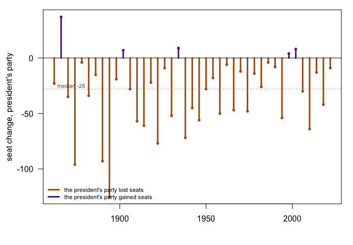

**Figure 1. Every midterm since 1862, by the seat change for the president’s party.** One vertical line per election, because the claim is about the direction of 41 separate events, and direction reads instantly as which side of zero a line falls. The dotted line is the **median**, -28 seats — the middle midterm, with as many above it as below. The chamber grew from 183 seats to 437 across this figure, so the buttons on the interactive version restate each change as a share of the chamber; in print the axis is raw seats.

With few exceptions, the observation holds. The exceptions get their story told, because each one is informative:

| Year | President’s party | Seat change | Chamber size |
| --- | --- | --- | --- |
| 1866 | R | 37 | 226 |
| 1902 | R | 7 | 386 |
| 1934 | D | 9 | 435 |
| 1998 | D | 4 | 435 |
| 2002 | R | 8 | 435 |

**2002** is the modern one: President Bush’s approval was extraordinarily high in the year after the September 11 attacks,[^1] and the districts had just been freshly redrawn after the 2000 census. **1998** came at the height of the impeachment proceedings against President Clinton,[^2] with a booming economy underneath them; the punishment landed on the punishers. **1934** was the depth of the Depression and the height of the New Deal, and voters gave Roosevelt’s party more of the House rather than less. **1902** is partly arithmetic: the chamber itself grew by 29 seats after the 1900 census, so both parties gained, though the Democrats gained more. And **1866** is not what it looks like. Congress was refusing to seat delegations from the former Confederacy,[^3] so the chamber is not comparable to the one before it, and the +37 partly measures an argument about who counts as a state.

Because 1866 is a genuinely bad case, drop it — and everything before 1878 with it. The rule barely notices: the loss rate moves from 88% to 89%, and the average change from -32.5 to -32.8 seats. The corollary cuts both ways: if no single bad case can move the result, no single good case is holding it up either.

So the direction is close to a certainty. The size is not, and the size is what decides who writes the laws.

| Statistic | Value |
| --- | --- |
| Median loss | -28 seats |
| Within 10 seats of the median | 10 of 41 midterms (24%) |
| Middle half of outcomes (25th to 75th percentile) | -52 to -9 seats |
| Standard deviation | 32.3 seats |
| Full range | -125 to +37 seats |

**Only 10 of 41 midterms, or 24%, land within ten seats of the median.** The middle half of the outcomes runs from a loss of 52 seats to a loss of 9. A forecast that says “you will lose between 9 and 52 seats, probably, and possibly 125” is not much of a forecast.

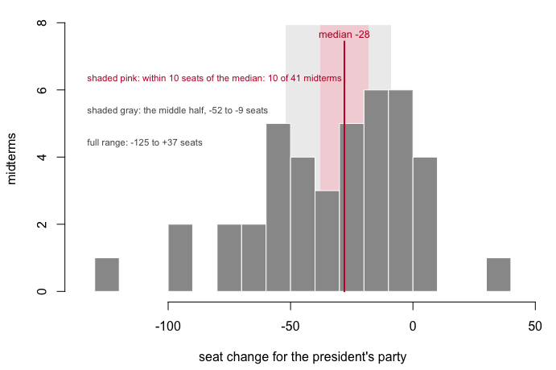

**Figure 2. The same 41 midterms, in bins of ten seats.** The red line is the median, -28 seats. The pink band is ten seats either side of it and holds 10 of the 41 midterms; the gray band is the middle half, -52 to -9 seats. A rule that gets the direction right nine times in ten sounds like a rule with a center, and this distribution barely has one.

And the consequence that matters most is nearly a coin flip:

| Quantity | Value |
| --- | --- |
| Midterms where the president’s party held a House majority going in | 17 |
| … of those, midterms where it lost the majority | 7 |
| As a percentage | 41% |

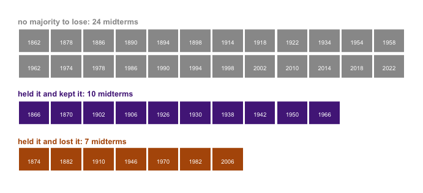

**Figure 3. What happened to the majority.** One square per midterm, grouped by whether the president’s party had a House majority — more than half the seats — going in, and whether it kept it. It entered 17 midterms holding a majority and lost it in 7 — 41%. The same elections that make the direction near-certain make the outcome anyone cares about close to a toss-up.

That is the finding, and it is worth saying in one breath. The most reliable regularity in American politics gets the direction of a national election right 88% of the time, and tells you almost nothing about who ends up running the House.

## What this brief cannot tell you

**It cannot tell you why the penalty happens.** Four accounts have competed for sixty years. Campbell’s surge and decline[^4] says the presidential-year electorate stays home, and Tufte’s referendum[^5] says voters punish the president over the economy. Erikson’s penalty[^6] says the midterm electorate marks down whichever party holds the White House. And Bafumi, Erikson and Wlezien’s balancing[^7] says voters deliberately moderate policy. All four fit this table of seat changes equally well, and nothing in the table separates them.

**It cannot turn a seat change into a vote change.** A seat swing depends on the district map as much as on the electorate, and there is no vote column here. Mayhew’s vanishing marginals[^8] (fewer districts sitting near even, so a given swing moves fewer seats) is a live alternative reading of any trend in the penalty, and it cannot be tested in this file.

**It cannot vouch for its one hand-made column.** `pres_party` was typed in from the historical record, and it is the most likely place in the file for a mistake to hide. Anyone can check it in a minute, and it is still the only column nobody downloaded.

**And 41 cases is a small sample.** Any claim about a subgroup of midterms (an era, a president’s second term) rests on a handful of elections, and moving one boundary can produce almost any story.

## What you should have learned

- The president’s party has lost House seats in 36 of 41 midterms, or 88%, and the median change is -28 seats.
- The exceptions have stories, not noise: 2002 (a president at peak approval after September 11, on freshly redrawn districts), 1998, 1934, 1902, and 1866, which measures Reconstruction rather than an electorate.
- The rule is a direction, not a size: only 10 of 41 midterms land within ten seats of the median, and the middle half spans -52 to -9 seats.
- The president’s party held a House majority entering 17 midterms and lost it in 7 of them — 41%, roughly a coin flip on the outcome that decides who governs.
- The seat counts are the House counting itself, taken from one page the House Historian publishes; the party of the president is the one column that had to be typed in by hand.

## Extensions

None of these is answered above, and every one can be answered from the table the Sources section hands over.

- `house_midterms.csv` has `pres_party_change` for every election, with a `midterm` flag. Compute the loss rate for midterms and for presidential years separately. Is this a midterm penalty, or a penalty on whichever party holds the White House, in every kind of year?
- Sort the midterms by `pres_party_change` and read the tails. How many of the worst ten losses came when the president’s party also entered with a large majority — is some of the penalty just having more seats to lose?
- `seats` changes across the series. Recompute each midterm change as a share of `seats` and re-rank the ten worst. Which elections move most when the unit changes?
- Filter to rows where `pres_party_change` is positive and `midterm` is true, and read the history of each year you find. Do the exceptions share anything you could have known in advance?
- **Stretch.** Gallup publishes presidential approval back to the 1940s. Put each postwar midterm’s approval number beside its seat change and ask whether approval predicts the size of the loss, which this file cannot.
- **Stretch.** The Senate’s own site publishes its party divisions. Build the same table for the Senate, where only a third of the seats are on the ballot, and see whether the penalty survives the change of chamber.

## Sources

**Data**

- Office of the Historian, U.S. House of Representatives, *Party Divisions of the House of Representatives, 1789 to Present* (https://history.house.gov/Institution/Party-Divisions/Party-Divisions/). The party of the president at each election is a hand-built lookup, typed in from the historical record.

**The data itself**

Every figure above is drawn from this table. It is plain CSV, it opens in a spreadsheet, and it is yours to take further.

`house_midterms.csv`

**Academic literature**

- Bafumi, J., Erikson, R. S. and Wlezien, C. (2010). “Balancing, Generic Polls and Midterm Congressional Elections.” *Journal of Politics* 72(3): 705–719.
- Campbell, A. (1960). “Surge and Decline: A Study of Electoral Change.” *Public Opinion Quarterly* 24(3): 397–418.
- Erikson, R. S. (1988). “The Puzzle of Midterm Loss.” *Journal of Politics* 50(4): 1011–1029.
- Mayhew, D. R. (1974). “Congressional Elections: The Case of the Vanishing Marginals.” *Polity* 6(3): 295–317.
- Tufte, E. R. (1975). “Determinants of the Outcomes of Midterm Congressional Elections.” *American Political Science Review* 69(3): 812–826.

Rebuild this data yourself, with an AI assistant

```
I want to rebuild a public dataset from its original source, without any
starting files. Please do the following and show your work.

THE SOURCE. Office of the Historian, U.S. House of Representatives,
"Party Divisions of the House of Representatives, 1789 to Present":
https://history.house.gov/Institution/Party-Divisions/Party-Divisions/
One web page holding one table. Each row is a Congress, with the total
number of seats and how many each party held. It is the House's own
count, and the authority on the question. No account or key is needed.

HOW TO DOWNLOAD IT. Two things to know. The site refuses requests that do not
identify themselves as a browser, so send a browser user-agent header.
And the table's footnote markers sit inside the cells: strip the HTML
tags naively and 435 with footnote 5 comes out as "4355". Any seat
count above 999 is a footnote stuck to a real number — keep the first
three digits.

WHAT TO BUILD.
1. One row per House election from 1858 onward: the election year, the
   total seats, and the Democratic and Republican seat counts.
2. Mark which elections were midterms, work out which party held the
   presidency going into each one, and compute how many seats the
   president's party gained or lost. Report the average midterm change.

CHECK YOUR WORK. The copy this book used was downloaded in August 2026.
If your rebuild matches it, you should find:
- 84 elections, 1858 through 2024
- the first row, 1858: 238 seats, 83 Democrats, 116 Republicans
- 2018: 235 Democrats, 199 Republicans — the president's party down 42
- 435 seats in 55 of the 84 elections, and briefly 436 then 437 when
  Alaska and Hawaii joined ahead of the 1960s reapportionment
The Historian adds a row after each election and otherwise leaves the
past alone; a new bottom row means time passed, not that you erred.
```

[^1]: Gallup’s approval series for George W. Bush: https://news.gallup.com/poll/116500/presidential-approval-ratings-george-bush.aspx.
[^2]: Office of the House Historian, “The impeachment of President William J. Clinton”: https://history.house.gov/Historical-Highlights/1951-2000/The-impeachment-of-President-William-J-Clinton/.
[^3]: Office of the House Historian, “The Joint Committee on Reconstruction”: https://history.house.gov/Historical-Highlights/1851-1900/The-Joint-Committee-on-Reconstruction/.
[^4]: Angus Campbell, “Surge and Decline: A Study of Electoral Change,” *Public Opinion Quarterly* 24, no. 3 (1960): 397–418, https://doi.org/10.1086/266960.
[^5]: Edward R. Tufte, “Determinants of the Outcomes of Midterm Congressional Elections,” *American Political Science Review* 69, no. 3 (1975): 812–826, https://doi.org/10.2307/1958391.
[^6]: Robert S. Erikson, “The Puzzle of Midterm Loss,” *Journal of Politics* 50, no. 4 (1988): 1011–1029, https://doi.org/10.2307/2131389.
[^7]: Joseph Bafumi, Robert S. Erikson and Christopher Wlezien, “Balancing, Generic Polls and Midterm Congressional Elections,” *Journal of Politics* 72, no. 3 (2010): 705–719, https://doi.org/10.1017/S0022381610000113.
[^8]: David R. Mayhew, “Congressional Elections: The Case of the Vanishing Marginals,” *Polity* 6, no. 3 (1974): 295–317, https://doi.org/10.2307/3233931.